# Exploratory Data Analysis gives us an insight into the data. It can showcase a story of the data and hence is a vital part of machine learning.

Importing necessary packages

```python
import pandas as pd
import numpy as np
import numpy as np
import pandas as pd
import matplotlib.pyplot as plt
import seaborn as sns
import matplotlib.pyplot as plt
import seaborn as sns
```

Loading the cleaned dataset for our exploration study.

```python
load_data=pd.read_csv("CleanedLoandata.csv",encoding = "ISO-8859-1")
```

```python
load_data.columns
```

```
Index(['loan_amnt', 'funded_amnt', 'funded_amnt_inv', 'term', 'int_rate',
       'installment', 'grade', 'emp_length', 'home_ownership', 'annual_inc',
       ...
       'total_bal_ex_mort', 'total_bc_limit', 'total_il_high_credit_limit',
       'hardship_flag', 'disbursement_method', 'debt_settlement_flag',
       'timestamp', 'issue_year', 'issue_month', 'Risk_Score'],
      dtype='object', length=109)
```

### Exploratory Data Analysis of Accepted Loan Data

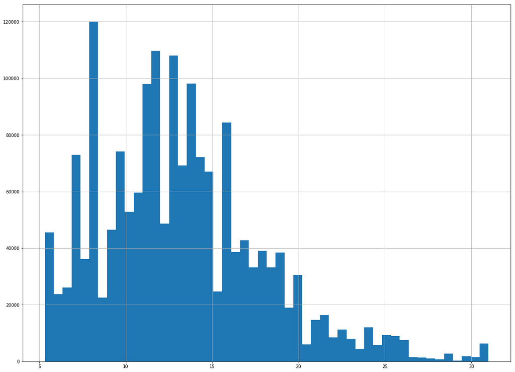

```python
load_data['int_rate'].hist(bins=50,figsize=(20,15))
plt.show()
```

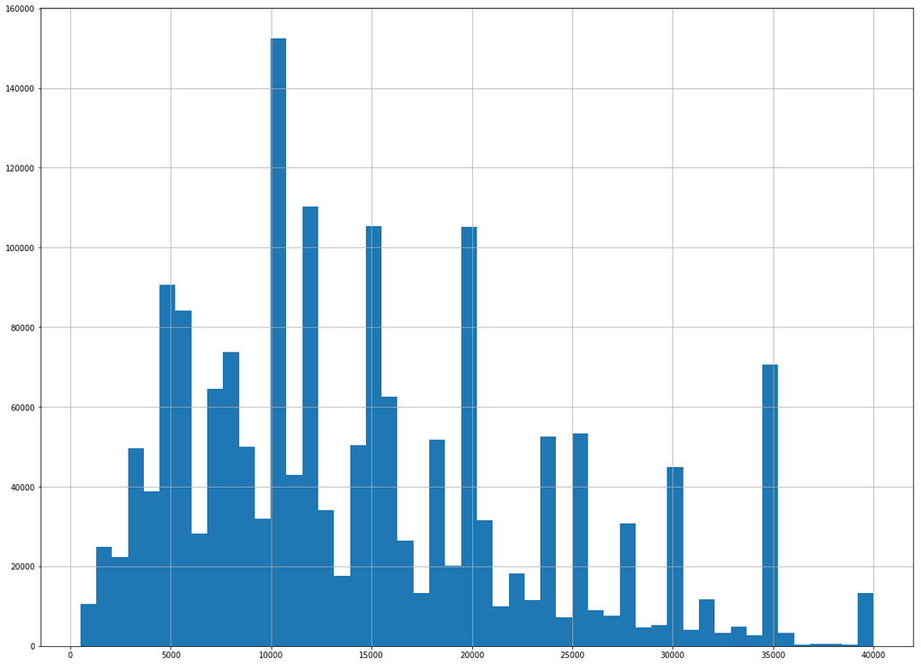

```python
## Distribution of Loan Amount
load_data['loan_amnt'].hist(bins=50,figsize=(20,15))
plt.show()
```

#### Study of Loan Amount

```python
## Study of Loan Amount
load_data['loan_amnt'].describe()
```

```
count    1.765420e+06
mean     1.477257e+04
std      8.886956e+03
min      5.000000e+02
25%      8.000000e+03
50%      1.260000e+04
75%      2.000000e+04
max      4.000000e+04
Name: loan_amnt, dtype: float64
```

#### Study of Interest Rate

We are analysing the the minimum, maximum mean values of Interest rate present in the data. The mean interest rate is 13.21% and the max interest rate is 30 %

```python
## Study of Interest Rate
load_data['int_rate']=pd.Series(load_data['int_rate']).convert_objects(convert_numeric=True)
load_data['int_rate'].describe()
```

```
count    1.765420e+06
mean     1.319550e+01
std      4.733938e+00
min      5.320000e+00
25%      9.750000e+00
50%      1.274000e+01
75%      1.599000e+01
max      3.099000e+01
Name: int_rate, dtype: float64
```

#### Analysis of all column values

```python
## Study of all columns
load_data.describe()
```

|  | loan_amnt | funded_amnt | funded_amnt_inv | term | int_rate | installment | emp_length | home_ownership | annual_inc | verification_status | ... | percent_bc_gt_75 | pub_rec_bankruptcies | tax_liens | tot_hi_cred_lim | total_bal_ex_mort | total_bc_limit | total_il_high_credit_limit | issue_year | issue_month | Risk_Score |
| --- | --- | --- | --- | --- | --- | --- | --- | --- | --- | --- | --- | --- | --- | --- | --- | --- | --- | --- | --- | --- | --- |
| count | 1.765420e+06 | 1.765420e+06 | 1.765420e+06 | 1.765420e+06 | 1.765420e+06 | 1.765420e+06 | 1.765420e+06 | 1.765420e+06 | 1.765420e+06 | 1.765420e+06 | ... | 1.765420e+06 | 1.765420e+06 | 1.765420e+06 | 1.765420e+06 | 1.765420e+06 | 1.765420e+06 | 1.765420e+06 | 1.765420e+06 | 1.765420e+06 | 1.765420e+06 |
| mean | 1.477257e+04 | 1.476582e+04 | 1.474342e+04 | 4.280189e+01 | 1.319550e+01 | 4.399800e+02 | 5.696499e+00 | 6.033442e-01 | 7.740295e+04 | 6.806528e-01 | ... | 4.342328e+01 | 1.294140e-01 | 5.682557e-02 | 1.692684e+05 | 4.932489e+04 | 2.155868e+04 | 4.144252e+04 | 2.015257e+03 | 6.778421e+00 | 6.983959e+02 |
| std | 8.886956e+03 | 8.884320e+03 | 8.888973e+03 | 1.081571e+01 | 4.733938e+00 | 2.610755e+02 | 3.753289e+00 | 4.892035e-01 | 1.185159e+05 | 4.662239e-01 | ... | 3.644393e+01 | 3.722915e-01 | 4.155449e-01 | 1.791341e+05 | 4.888966e+04 | 2.201952e+04 | 4.410049e+04 | 1.570505e+00 | 3.422322e+00 | 3.176442e+01 |
| min | 5.000000e+02 | 5.000000e+02 | 0.000000e+00 | 3.600000e+01 | 5.320000e+00 | 4.930000e+00 | 0.000000e+00 | 0.000000e+00 | 0.000000e+00 | 0.000000e+00 | ... | 0.000000e+00 | 0.000000e+00 | 0.000000e+00 | 0.000000e+00 | 0.000000e+00 | 0.000000e+00 | 0.000000e+00 | 2.007000e+03 | 1.000000e+00 | 6.120000e+02 |
| 25% | 8.000000e+03 | 8.000000e+03 | 8.000000e+03 | 3.600000e+01 | 9.750000e+00 | 2.513600e+02 | 2.000000e+00 | 0.000000e+00 | 4.600000e+04 | 0.000000e+00 | ... | 0.000000e+00 | 0.000000e+00 | 0.000000e+00 | 4.563400e+04 | 1.987200e+04 | 7.400000e+03 | 1.261800e+04 | 2.014000e+03 | 4.000000e+00 | 6.720000e+02 |
| 50% | 1.260000e+04 | 1.257500e+04 | 1.250000e+04 | 3.600000e+01 | 1.274000e+01 | 3.763700e+02 | 6.000000e+00 | 1.000000e+00 | 6.500000e+04 | 1.000000e+00 | ... | 4.000000e+01 | 0.000000e+00 | 0.000000e+00 | 1.050370e+05 | 3.685600e+04 | 1.500000e+04 | 3.083000e+04 | 2.015000e+03 | 7.000000e+00 | 6.920000e+02 |
| 75% | 2.000000e+04 | 2.000000e+04 | 2.000000e+04 | 6.000000e+01 | 1.599000e+01 | 5.815800e+02 | 1.000000e+01 | 1.000000e+00 | 9.200000e+04 | 1.000000e+00 | ... | 7.500000e+01 | 0.000000e+00 | 0.000000e+00 | 2.476410e+05 | 6.277900e+04 | 2.830000e+04 | 5.644600e+04 | 2.017000e+03 | 1.000000e+01 | 7.120000e+02 |
| max | 4.000000e+04 | 4.000000e+04 | 4.000000e+04 | 6.000000e+01 | 3.099000e+01 | 1.719830e+03 | 1.000000e+01 | 1.000000e+00 | 1.100000e+08 | 1.000000e+00 | ... | 1.000000e+02 | 1.200000e+01 | 8.500000e+01 | 9.999999e+06 | 3.408095e+06 | 1.105500e+06 | 2.101913e+06 | 2.017000e+03 | 1.200000e+01 | 8.475000e+02 |

8 rows × 95 columns

#### Calculating Risk_Score

```python
load_data['Risk_Score'] = (load_data.fico_range_low + load_data.fico_range_high) / 2
load_data['issue_year'] = load_data['issue_year'].astype(int)
```

### Distribution of Risk Score

We notice that most of the Risk Scores are between the range of 600 and 830. This must be the case as these borrowers have approved loans hence, their Risk Scores will be in a good range

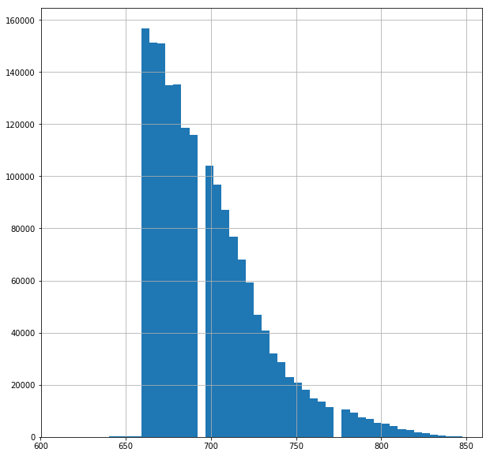

```python
load_data['Risk_Score'].hist(bins=50,figsize=(10,10))
plt.show()
```

#### Analysis of Risk Score with Issue Year

We note that the mean risk score does not change significantly

```
    issue_year        mean
10        2017  702.296764
9         2016  697.378663
8         2015  695.649960
7         2014  694.497345
6         2013  696.998338
5         2012  703.387407
4         2011  716.991713
3         2010  715.041796
2         2009  716.965916
1         2008  699.101964
0         2007  691.966833
```

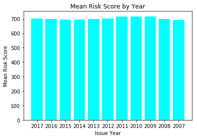

```python
import seaborn as sns
# sns.set(style="whitegrid")
risk_trend=load_data[['issue_year','Risk_Score']].groupby(['issue_year'])['Risk_Score'].mean().reset_index(name='mean').sort_values(['issue_year'],ascending=False)
print(risk_trend)
# g = sns.factorplot(x="issue_year", y="count", hue="Approval", data=approval_trend,size=7, kind="bar", palette="muted")
# g.despine(left=True)
# plt.show()
# flights = risk_trend.pivot("issue_year", "mean")
# ax = sns.heatmap(risk_trend['issue_year'])

##Analysis of Average Interest Rate by Issue Year
##Mean Interest Rate was maximum in year 2013


x = np.array(range(len(risk_trend)))
y = risk_trend['mean']
my_xticks = risk_trend['issue_year']
#plt.xticks(count_code.index, count_code['code'], rotation=90,y='count')
plt.xticks(x, my_xticks)
#plt.plot(x,y)
#plt.xticks(rotation=70)
plt.bar(x,y,color='cyan')
plt.title('Mean Risk Score by Year')
plt.ylabel('Mean Risk Score')
plt.xlabel('Issue Year')
# plt.savefig(os.path.join('Part1','TimeSeries.png'),dpi=100)
#droppingcolumn fintime
plt.show()
plt.clf()
```

### Analysis of Interest Rate by Issue Year

```
    issue_year       mean
0         2007  11.825108
1         2008  12.061964
2         2009  12.437247
3         2010  11.985268
4         2011  12.223365
5         2012  13.637707
6         2013  14.532014
7         2014  13.769482
8         2015  12.599691
9         2016  13.042165
10        2017  13.245785
```

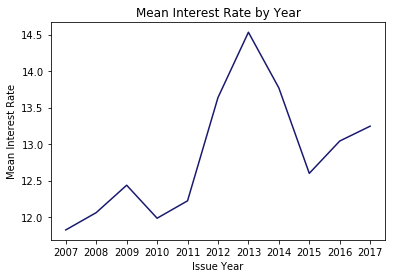

```python
##Analysis of Average Interest Rate by Issue Year
##Mean Interest Rate was maximum in year 2013
load_data['issue_year'] = load_data['issue_year'].astype(int)
interestrate_trend=load_data[['int_rate','issue_year']].groupby(['issue_year'])['int_rate'].mean().reset_index(name='mean').sort_values(['issue_year'],ascending=True)
print(interestrate_trend)

x = np.array(range(len(interestrate_trend)))
y = interestrate_trend['mean']
my_xticks = interestrate_trend['issue_year']
#plt.xticks(count_code.index, count_code['code'], rotation=90,y='count')
plt.xticks(x, my_xticks)
#plt.plot(x,y)
#plt.xticks(rotation=70)
plt.plot(x,y,color='midnightblue')
plt.title('Mean Interest Rate by Year')
plt.ylabel('Mean Interest Rate')
plt.xlabel('Issue Year')
# plt.savefig(os.path.join('Part1','TimeSeries.png'),dpi=100)
#droppingcolumn fintime
plt.show()
plt.clf()
```

### Analysis of Loan Amount with Issue year

```
    issue_year          mean
0         2007   8254.519071
1         2008   8825.428333
2         2009   9833.033516
3         2010  10528.240408
4         2011  12047.503568
5         2012  13461.763796
6         2013  14707.413733
7         2014  14870.232083
8         2015  15240.279879
9         2016  14734.039046
10        2017  14845.060463
```

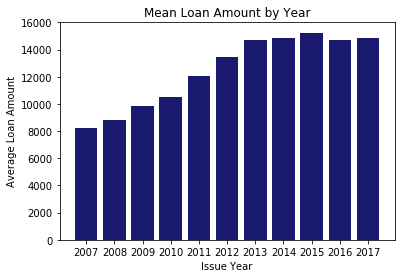

```python
##Analysis of Average Interest Rate by Issue Year
##Average loan amount was the highest in issue year 2015
# load_data['issue_year'] = load_data['issue_year'].astype(int)
loan_trend=load_data[['loan_amnt','issue_year']].groupby(['issue_year'])['loan_amnt'].mean().reset_index(name='mean').sort_values(['issue_year'],ascending=True)
print(loan_trend)

x = np.array(range(len(loan_trend)))
y = loan_trend['mean']
my_xticks = loan_trend['issue_year']
#plt.xticks(count_code.index, count_code['code'], rotation=90,y='count')
plt.xticks(x, my_xticks)
#plt.plot(x,y)
#plt.xticks(rotation=70)
plt.bar(x,y,color='midnightblue')
plt.title('Mean Loan Amount by Year')
plt.ylabel('Average Loan Amount')
plt.xlabel('Issue Year')
# plt.savefig(os.path.join('Part1','TimeSeries.png'),dpi=100)
#droppingcolumn fintime
plt.show()
plt.clf()
```

### Analysis of Loans funded by Issue Year

```
    issue_year          mean
0         2007   8254.519071
1         2008   8825.428333
2         2009   9833.033516
3         2010  10528.240408
4         2011  12047.503568
5         2012  13461.763796
6         2013  14707.413733
7         2014  14870.232083
8         2015  15240.279879
9         2016  14734.039046
10        2017  14845.060463
```

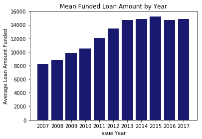

```python
##Analysis of Average Interest Rate by Issue Year
##Average loan amount was the highest in issue year 2015
# load_data['issue_year'] = load_data['issue_year'].astype(int)
funded_amnt_trend=load_data[['funded_amnt','issue_year']].groupby(['issue_year'])['funded_amnt'].mean().reset_index(name='mean').sort_values(['issue_year'],ascending=True)
print(loan_trend)

x = np.array(range(len(loan_trend)))
y = loan_trend['mean']
my_xticks = loan_trend['issue_year']
#plt.xticks(count_code.index, count_code['code'], rotation=90,y='count')
plt.xticks(x, my_xticks)
#plt.plot(x,y)
#plt.xticks(rotation=70)
plt.bar(x,y,color='midnightblue')
plt.title('Mean Funded Loan Amount by Year')
plt.ylabel('Average Loan Amount Funded')
plt.xlabel('Issue Year')
# plt.savefig(os.path.join('Part1','TimeSeries.png'),dpi=100)
#droppingcolumn fintime
plt.show()
plt.clf()
```

### Analysis of Mean Loan Amount by State

The state is the field provided by the borrower during loan application. Hence, we tried to analyse if Mean loan Amounts granted by state. The Maximum mean loan amount was provided to Alaska but remains consostent for the other states.

```
   addr_state          mean
4          13   8148.214286
19         27  13634.477190
41         47  13634.812219
22          3  13831.871984
31         38  13842.050491
23         30  13852.650258
36         42  13866.968548
34         40  13998.139535
5          14  14043.754879
1          10  14050.772253
27         34  14069.383436
15         23  14087.236600
29         36  14103.404687
9          18  14132.972902
```

[output cut: 37 more lines]

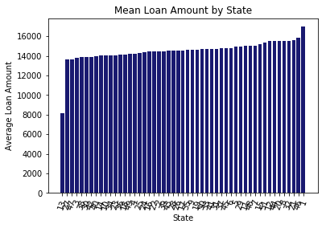

```python
###Analysis of average interest rate by states
### We observe that the average loan amount is the highest for Alaska
load_data['addr_state'] = load_data['addr_state'].astype(str)
state_loan=load_data[['loan_amnt','addr_state']].groupby(['addr_state'])['loan_amnt'].mean().reset_index(name='mean').sort_values(['mean'],ascending=True)
print(state_loan)


x = np.array(range(len(state_loan)))
y = state_loan['mean']
my_xticks = state_loan['addr_state']
#plt.xticks(count_code.index, count_code['code'], rotation=90,y='count')
plt.xticks(x, my_xticks)
#plt.plot(x,y)
plt.xticks(rotation=70)
plt.rcParams["figure.figsize"] = (10,15)
plt.bar(x,y,color='midnightblue')

plt.title('Mean Loan Amount by State')
plt.ylabel('Average Loan Amount')
plt.xlabel('State')

# plt.savefig(os.path.join('Part1','TimeSeries.png'),dpi=100)
#droppingcolumn fintime
plt.show()
plt.clf()
```

### Analysis of Interest Rates by State

We observe that the interest rates are also close to consistent and the mean interest rate is the highest for Hawaii

```
   addr_state       mean
49          8  12.587068
4          13  12.631429
12         20  12.745290
24         31  12.805174
41         47  12.949431
43         49  12.953716
14         22  12.972915
47          6  13.024629
19         27  13.028236
31         38  13.041438
6          15  13.059392
44          5  13.078261
33          4  13.080045
25         32  13.087000
```

[output cut: 37 more lines]

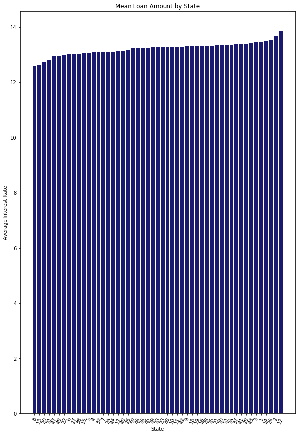

```python
load_data['addr_state'] = load_data['addr_state'].astype(str)
state_loan=load_data[['int_rate','addr_state']].groupby(['addr_state'])['int_rate'].mean().reset_index(name='mean').sort_values(['mean'],ascending=True)
print(state_loan)


x = np.array(range(len(state_loan)))
y = state_loan['mean']
my_xticks = state_loan['addr_state']
#plt.xticks(count_code.index, count_code['code'], rotation=90,y='count')
plt.xticks(x, my_xticks)
#plt.plot(x,y)
plt.xticks(rotation=70)
plt.rcParams["figure.figsize"] = (10,15)
plt.bar(x,y,color='midnightblue')

plt.title('Mean Loan Amount by State')
plt.ylabel('Average Interest Rate')
plt.xlabel('State')

# plt.savefig(os.path.join('Part1','TimeSeries.png'),dpi=100)
#droppingcolumn fintime
plt.show()
plt.clf()
```

```
   addr_state           sum
4          13   8148.214286
19         27  13634.477190
41         47  13634.812219
22          3  13831.871984
31         38  13842.050491
23         30  13852.650258
36         42  13866.968548
34         40  13998.139535
5          14  14043.754879
1          10  14050.772253
27         34  14069.383436
15         23  14087.236600
29         36  14103.404687
9          18  14132.972902
```

[output cut: 37 more lines]

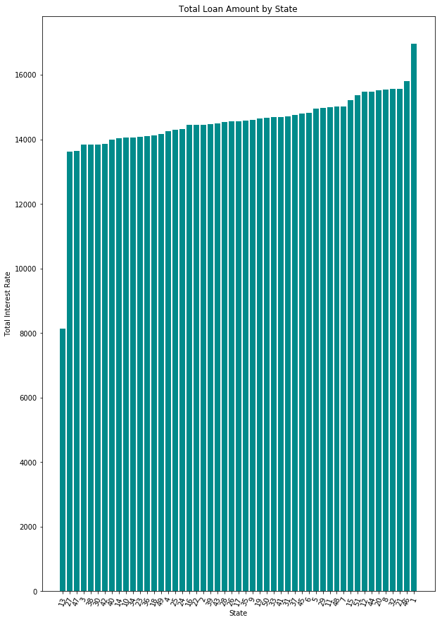

```python
load_data['addr_state'] = load_data['addr_state'].astype(str)
state_loan=load_data[['loan_amnt','addr_state']].groupby(['addr_state'])['loan_amnt'].mean().reset_index(name='sum').sort_values(['sum'],ascending=True)
print(state_loan)


x = np.array(range(len(state_loan)))
y = state_loan['sum']
my_xticks = state_loan['addr_state']
#plt.xticks(count_code.index, count_code['code'], rotation=90,y='count')
plt.xticks(x, my_xticks)
#plt.plot(x,y)
plt.xticks(rotation=70)
plt.rcParams["figure.figsize"] = (10,15)
plt.bar(x,y,color='darkcyan')

plt.title('Total Loan Amount by State')
plt.ylabel('Total Interest Rate')
plt.xlabel('State')

# plt.savefig(os.path.join('Part1','TimeSeries.png'),dpi=100)
#droppingcolumn fintime
plt.show()
plt.clf()
```